# AS3-1: 數位偵探

第 17 組

2019-03-11 14:49:56

犯罪是一個國際關注的問題，但它在不同的國家以不同的方式記錄和處理。 在美國，聯邦調查局（FBI）記錄了暴力犯罪和財產犯罪。 此外，每個城市都記錄了犯罪行為，一些城市發布了有關犯罪率的數據。 伊利諾伊州芝加哥市從2001年開始在線發布犯罪數據。

芝加哥是美國人口第三多的城市，人口超過270萬。在這個作業裡面，我們將關注一種特定類型的財產犯罪，稱為「汽車盜竊」，我們將使用R中的一些基本數據分析來了解芝加哥的汽車盜竊紀錄。請載入文件“data/mvtWeek1.csv”：以下是各欄位的描述：

- `ID`: a unique identifier for each observation
- `Date`: the date the crime occurred
- `LocationDescription`: the location where the crime occurred
- `Arrest`: whether or not an arrest was made for the crime (TRUE if an arrest was made, and FALSE if an arrest was not made)
- `Domestic`: whether or not the crime was a domestic crime, meaning that it was committed against a family member (TRUE if it was domestic, and FALSE if it was not domestic)
- `Beat`: the area, or “beat” in which the crime occurred. This is the smallest regional division defined by the Chicago police department.
- `District`: the police district in which the crime occured. Each district is composed of many beats, and are defined by the Chicago Police Department.
- `CommunityArea`: the community area in which the crime occurred. Since the 1920s, Chicago has been divided into what are called “community areas”, of which there are now 77. The community areas were devised in an attempt to create socially homogeneous regions.
- `Year`: the year in which the crime occurred.
- `Latitude`: the latitude of the location at which the crime occurred.
- `Longitude`: the longitude of the location at which the crime occurred.

### Section-1 Loading the Data

【1.1】How many rows of data (observations) are in this dataset?

```r
#載入csv檔
data = read.csv("data/mvtWeek1.csv")
#data筆數
nrow(data)
```

```
[1] 191641
```

答案：191641筆

檢查各欄位的資料格式

```r
#用summary檢查各欄位的資料格式
summary(data)
```

```
       ID                      Date                            LocationDescription
 Min.   :1310022   5/16/08 0:00  :    11   STREET                        :156564
 1st Qu.:2832144   10/17/01 22:00:    10   PARKING LOT/GARAGE(NON.RESID.): 14852
 Median :4762956   4/13/04 21:00 :    10   OTHER                         :  4573
 Mean   :4968629   9/17/05 22:00 :    10   ALLEY                         :  2308
 3rd Qu.:7201878   10/12/01 22:00:     9   GAS STATION                   :  2111
 Max.   :9181151   10/13/01 22:00:     9   DRIVEWAY - RESIDENTIAL        :  1675
                   (Other)       :191582   (Other)                       :  9558
   Arrest         Domestic            Beat         District     CommunityArea
 Mode :logical   Mode :logical   Min.   : 111   Min.   : 1      Min.   : 0
 FALSE:176105    FALSE:191226    1st Qu.: 722   1st Qu.: 6      1st Qu.:22
 TRUE :15536     TRUE :415       Median :1121   Median :10      Median :32
                                 Mean   :1259   Mean   :12      Mean   :38
                                 3rd Qu.:1733   3rd Qu.:17      3rd Qu.:60
                                 Max.   :2535   Max.   :31      Max.   :77
                                                NA's   :43056   NA's   :24616
      Year         Latitude      Longitude
 Min.   :2001   Min.   :41.6   Min.   :-87.9
 1st Qu.:2003   1st Qu.:41.8   1st Qu.:-87.7
 Median :2006   Median :41.9   Median :-87.7
 Mean   :2006   Mean   :41.8   Mean   :-87.7
 3rd Qu.:2009   3rd Qu.:41.9   3rd Qu.:-87.6
 Max.   :2012   Max.   :42.0   Max.   :-87.5
                NA's   :2276   NA's   :2276
```

類別(Factor) versus 字串(Character)

【1.2】How many variables are in this dataset?

```r
#用ncol找dataset中有多少變數
ncol(data)
```

```
[1] 11
```

答案：11

【1.3】Using the “max” function, what is the maximum value of the variable “ID”?

```r
#用max()找最大值
max(data$ID)
```

```
[1] 9181151
```

答案：9181151

【1.4】 What is the minimum value of the variable “Beat”?

```r
#用min()找最小值
min(data$Beat)
```

```
[1] 111
```

答案：111

【1.5】 How many observations have value TRUE in the Arrest variable (this is the number of crimes for which an arrest was made)?

```r
#用sum加總
sum(data$Arrest==TRUE)
```

```
[1] 15536
```

答案：15536

【1.6】 How many observations have a LocationDescription value of ALLEY?

```r
#
sum(data$LocationDescription=="ALLEY")
```

```
[1] 2308
```

答案：2308

### Section-2 Understanding Dates in R

【2.1】 In what format are the entries in the variable Date?

- Month/Day/Year Hour:Minute
- Day/Month/Year Hour:Minute
- Hour:Minute Month/Day/Year
- Hour:Minute Day/Month/Year

```r
#原本的格式
data$Date[1]
```

```
[1] 12/31/12 23:15
131680 Levels: 1/1/01 0:01 1/1/01 0:05 1/1/01 0:30 1/1/01 1:17 1/1/01 1:50 ... 9/9/12 9:50
```

```r
#轉換成日期格式後
data$Date = as.POSIXct(data$Date, format="%m/%d/%y %H:%M")
data$Date[1]
```

```
[1] "2012-12-31 23:15:00 CST"
```

答案：Month/Day/Year Hour:Minute

【2.2】 What is the month and year of the median date in our dataset?

```r
#用median函數找日期中位數
median(data$Date)
```

```
[1] "2006-05-21 12:30:00 CST"
```

答案：2006年5月

【2.3】 In which month did the fewest motor vehicle thefts occur?

```r
#以月份為分類加總各個月份的資料數
#再用sort由小到大排列後取最小的
sort(table(format(data$Date,"%m")))
```

```
   02    04    03    06    05    01    09    11    12    08    07    10
13511 15280 15758 16002 16035 16047 16060 16063 16426 16572 16801 17086
```

答案：2月

【2.4】 On which weekday did the most motor vehicle thefts occur?

```r
#將日期以星期(weekdays)為分類計算總數(table)後
#再用sort從大到小排序
data$Date %>% weekdays() %>% table() %>% sort(decreasing = TRUE)
```

```
.
 週五  週三  週一  週四  週六  週二  週日
29284 27416 27397 27319 27118 26791 26316
```

答案：週五

【2.5】 Which month has the largest number of motor vehicle thefts for which an arrest was made?

```r
#以月份為分類，計算逮捕的總數，再由大到小排列。
sort(tapply(data$Arrest,format(data$Date,"%m"),sum),decreasing = TRUE)
```

```
  01   12   10   08   07   03   11   04   09   02   06   05
1435 1397 1342 1329 1324 1298 1256 1252 1248 1238 1230 1187
```

答案：一月

### Section-3 Visualizing Crime Trends

【3.1】 (a) In general, does it look like crime increases or decreases from 2002 - 2012? (b) In general, does it look like crime increases or decreases from 2005 - 2008? (c) In general, does it look like crime increases or decreases from 2009 - 2011?

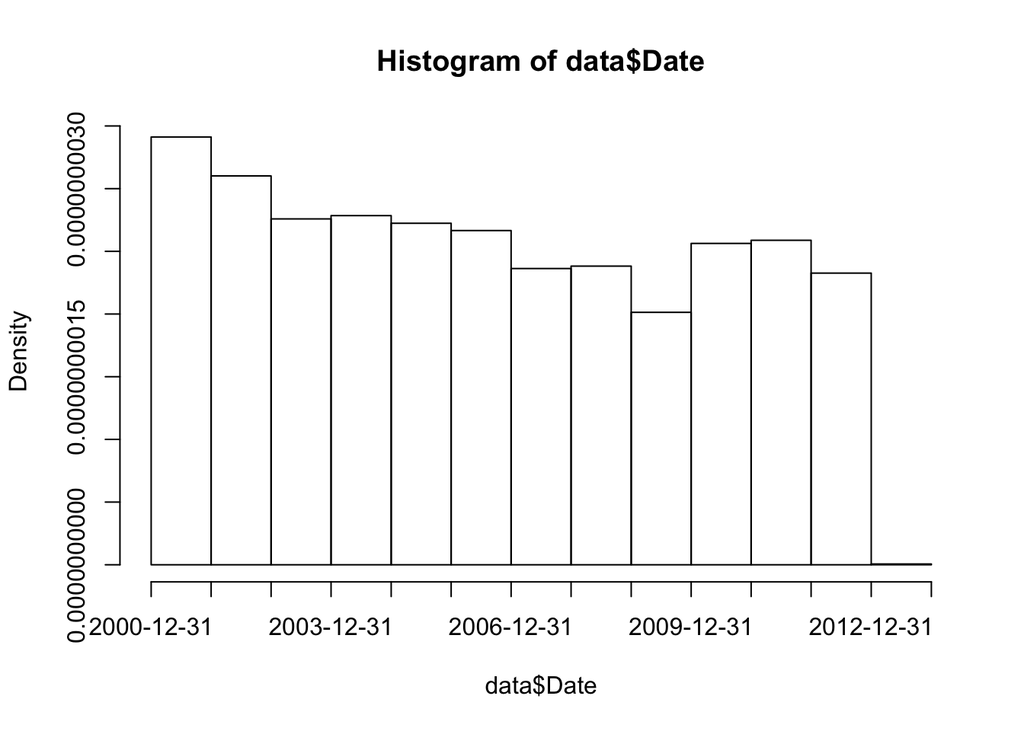

```r
library(ggplot2)
#用ggplot繪製折線圖
#dataPlot=ggplot(data,mapping = aes(x=data$Date,y=length(data))+geom_line()
hist(data$Date,'year')
```

【3.2】 Does it look like there were more crimes for which arrests were made in the first half of the time period or the second half of the time period?

```r
#先選出有逮捕到的資料
dataarrest = subset(data,data$Arrest==TRUE)
#以2007年為分界，計算前後兩階段的總數
table(dataarrest$Date>=as.POSIXct("2007-01-01"))
```

```
FALSE  TRUE
10588  4948
```

答案：有被逮捕的數量，在2007年以前比較多。

【3.3】 For what proportion of motor vehicle thefts in 2001 was an arrest made?

```r
#先取出2001年間的所有資料
data2001 = subset(data,Date>=as.POSIXct("2001-01-01") & Date<=as.POSIXct("2001-12-31"))

#再以年份、是否被逮捕計算總數後pipe到prop.table計算比率
table(data2001$Arrest,format(data2001$Date,"%Y")) %>% prop.table(2) %>% round(3)
```

```
         2001
  FALSE 0.896
  TRUE  0.104
```

答案：0.104

【3.4】 For what proportion of motor vehicle thefts in 2007 was an arrest made?

```r
#先取出2007年間的所有資料
data2007 = subset(data,Date>=as.POSIXct("2007-01-01") & Date<=as.POSIXct("2007-12-31"))

#再以年份、是否被逮捕計算總數後pipe到prop.table計算比率
table(data2007$Arrest,format(data2007$Date,"%Y")) %>% prop.table(2) %>% round(3)
```

```
         2007
  FALSE 0.915
  TRUE  0.085
```

答案：0.085

【3.5】 For what proportion of motor vehicle thefts in 2012 was an arrest made?

```r
##先取出2012年間的所有資料
data2012 = subset(data,Date>=as.POSIXct("2012-01-01") & Date<=as.POSIXct("2012-12-31"))

#再以年份、是否被逮捕計算總數後pipe到prop.table計算比率
table(data2012$Arrest,format(data2012$Date,"%Y")) %>% prop.table(2) %>% round(3)
```

```
         2012
  FALSE 0.961
  TRUE  0.039
```

答案：0.039

### Section-4 Popular Locations

【4.1】 Which locations are the top five locations for motor vehicle thefts, excluding the “Other” category? You should select 5 of the following options.

```r
#以地區為分類計算總數後排序
sort(table(data$LocationDescription),decreasing = TRUE)[1:6]
```

```
                        STREET PARKING LOT/GARAGE(NON.RESID.)
                        156564                          14852
                         OTHER                          ALLEY
                          4573                           2308
                   GAS STATION         DRIVEWAY - RESIDENTIAL
                          2111                           1675
```

答案：STREET、PARKING LOT/GARAGE(NON.RESID.)、ALLEY、GAS STATION、DRIVEWAY - RESIDENTIAL

【4.2】 How many observations are in Top5?

```r
#以地區為分類計算總數後排序，因為other排在第三，所以取出前六
#然後去除掉other所在的第三項資料後，將所有的數量加總
sum(sort(table(data$LocationDescription),decreasing = TRUE)[1:6][-3])
```

```
[1] 177510
```

答案：177510

【4.3】 One of the locations has a much higher arrest rate than the other locations. Which is it?

```r
topname = names(sort(table(data$LocationDescription),decreasing = TRUE)[1:6][-3])

topdata = subset(data,LocationDescription %in% topname)

tapply(topdata$Arrest,topdata$LocationDescription,mean) %>% sort(decreasing = TRUE)
```

```
                   GAS STATION PARKING LOT/GARAGE(NON.RESID.)
                       0.20796                        0.10793
                         ALLEY         DRIVEWAY - RESIDENTIAL
                       0.10789                        0.07881
                        STREET
                       0.07406
```

答案：GAS STATION

【4.4】 On which day of the week do the most motor vehicle thefts at gas stations happen?

```r
#取出地點在GAS STATION的資料後，以星期為分類傳入table()中計算總數
#然後再由大到小排序
data$Date[data$LocationDescription=="GAS STATION"] %>% weekdays() %>% table() %>% sort(decreasing = TRUE)
```

```
.
週六 週日 週五 週四 週一 週三 週二
 338  336  332  282  280  273  270
```

答案：週六

【4.5】 On which day of the week do the fewest motor vehicle thefts in residential driveways happen?

```r
#取出地點在DRIVEWAY - RESIDENTIAL的資料後，以星期為分類傳入table()中計算總數
#然後再由小到大排序
data$Date[data$LocationDescription=="DRIVEWAY - RESIDENTIAL"] %>% weekdays() %>% table() %>% sort()
```

```
.
週六 週日 週三 週二 週一 週五 週四
 202  221  234  243  255  257  263
```

答案：週六